# Problem Set 5

Benjamin Söllner

Oktober 2015

# Preparations

```r
library(ggplot2)
setwd('h:/Dokumente/GitHub/2015_Data_Analyst_Project_4/lesson5/')
```

# Questions about the Diamonds Dataset

```r
data(diamonds)
```

## 1- Price Histogram with Facet and Color

[output not shown]

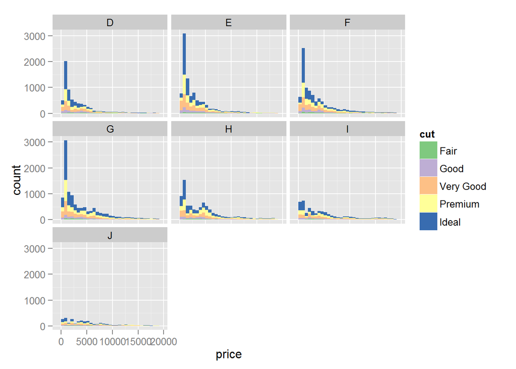

```r
# Create a histogram of diamond prices.
# Facet the histogram by diamond color
# and use cut to color the histogram bars.

# The plot should look something like this.
# http://i.imgur.com/b5xyrOu.jpg

# Note: In the link, a color palette of type
# 'qual' was used to color the histogram using
# scale_fill_brewer(type = 'qual')

# This assignment is not graded and
# will be marked as correct when you submit.

# ENTER YOUR CODE BELOW THIS LINE
# ===========================================
ggplot(data=diamonds, aes(x=price)) +
  geom_histogram(aes(fill=cut)) +
  scale_fill_brewer(type='qual') +
  facet_wrap(~color)
```

## 2- Price vs. Table Colored by Cut

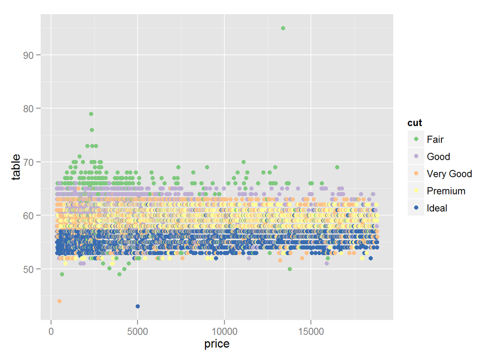

```r
# Create a scatterplot of diamond price vs.
# table and color the points by the cut of
# the diamond.

# The plot should look something like this.
# http://i.imgur.com/rQF9jQr.jpg

# Note: In the link, a color palette of type
# 'qual' was used to color the scatterplot using
# scale_color_brewer(type = 'qual')

# This assignment is not graded and
# will be marked as correct when you submit.

# ENTER YOUR CODE BELOW THIS LINE
# ===========================================
ggplot(data=diamonds, aes(x=price, y=table)) +
  geom_point(aes(color=cut)) +
  scale_color_brewer(type='qual')
```

## 3- Typical Table Value

**What is the typical table range for the majority of diamonds of *ideal* cut?** 53-57

**What is the typical table range for the majority of diamonds of *premium* cut?** 58-62

## 4- Price vs. Volume and Diamond Clarity

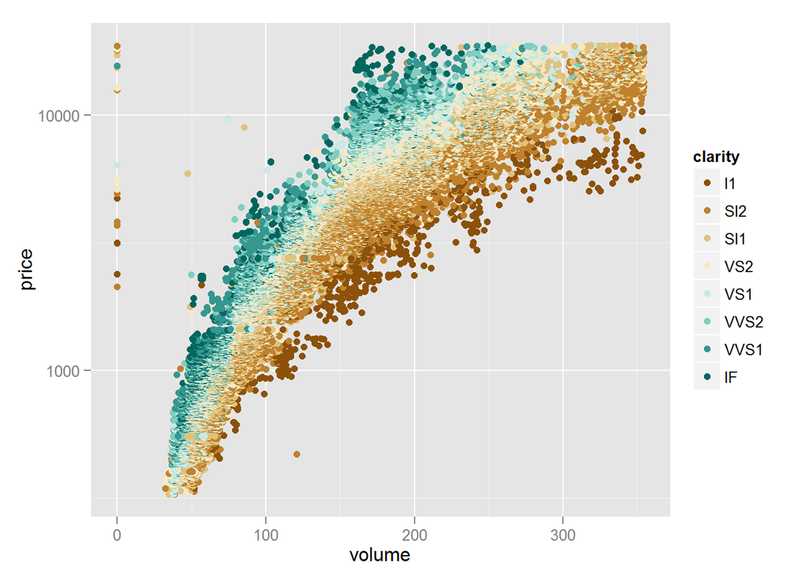

```r
# Create a scatterplot of diamond price vs.
# volume (x * y * z) and color the points by
# the clarity of diamonds. Use scale on the y-axis
# to take the log10 of price. You should also
# omit the top 1% of diamond volumes from the plot.

# Note: Volume is a very rough approximation of
# a diamond's actual volume.

# The plot should look something like this.
# http://i.imgur.com/excUpea.jpg

# Note: In the link, a color palette of type
# 'div' was used to color the scatterplot using
# scale_color_brewer(type = 'div')

# This assignment is not graded and
# will be marked as correct when you submit.

# ENTER YOUR CODE BELOW THIS LINE
# ===========================================
diamonds$volume = diamonds$x * diamonds$y * diamonds$z
ggplot(data=diamonds, aes(x=volume, y=price)) +
  geom_point(aes(color=clarity)) +
  scale_color_brewer(type='div') +
  scale_y_log10() +
  xlim(0, quantile(diamonds$volume, 0.99))
```

## Questions about the Facebook Dataset

```r
library(ggplot2)
pf <- read.delim('pseudo_facebook.tsv')
```

## 5- Proportion of Friendships Initiated

```r
# Many interesting variables are derived from two or more others.
# For example, we might wonder how much of a person's network on
# a service like Facebook the user actively initiated. Two users
# with the same degree (or number of friends) might be very
# different if one initiated most of those connections on the
# service, while the other initiated very few. So it could be
# useful to consider this proportion of existing friendships that
# the user initiated. This might be a good predictor of how active
# a user is compared with their peers, or other traits, such as
# personality (i.e., is this person an extrovert?).

# Your task is to create a new variable called 'prop_initiated'
# in the Pseudo-Facebook data set. The variable should contain
# the proportion of friendships that the user initiated.

# This programming assignment WILL BE automatically graded.

# DO NOT DELETE THIS NEXT LINE OF CODE
# ========================================================================
pf <- read.delim('pseudo_facebook.tsv')


# ENTER YOUR CODE BELOW THIS LINE
# ========================================================================
pf$prop_initiated = pf$friendships_initiated/pf$friend_count
```

## A Few Further Preparations For Upcoming Questions

```r
pf$year_joined =  floor(2014 - pf$tenure/365)
pf$year_joined.bucket <- cut(pf$year_joined, c(2004, 2009, 2011, 2012, 2014))
pf$prop_initiated = pf$friendships_initiated/pf$friend_count
pf.subset <- subset(pf, !is.na(prop_initiated))
```

## 6- prop_initiated vs. tenure

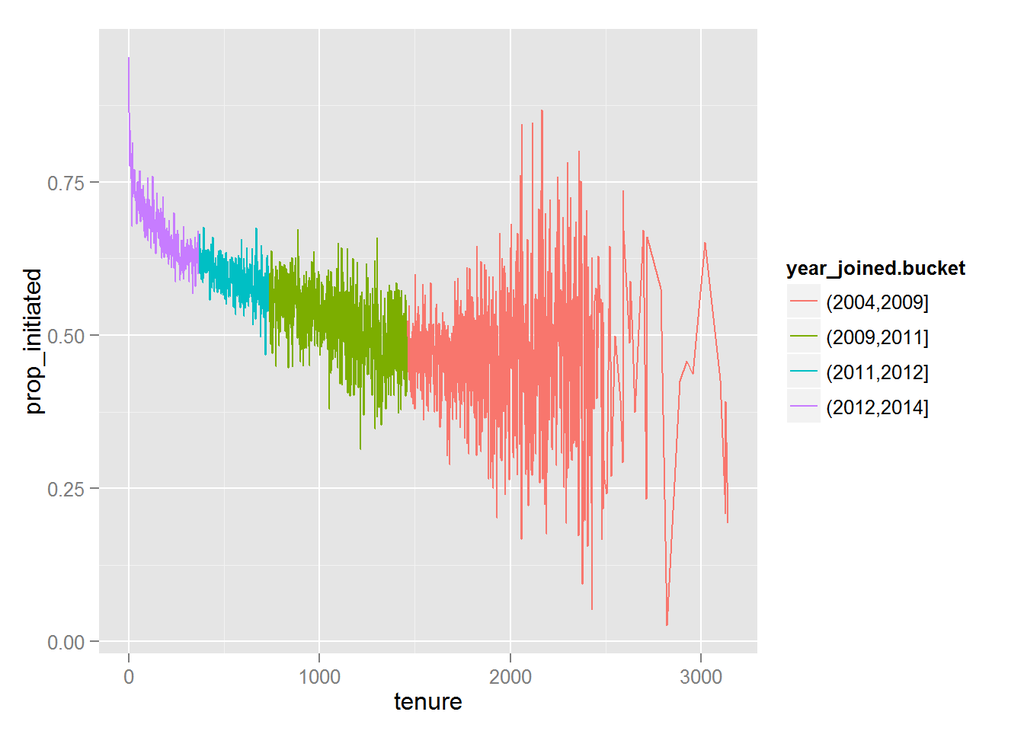

```r
# Create a line graph of the median proportion of
# friendships initiated ('prop_initiated') vs.
# tenure and color the line segment by
# year_joined.bucket.

# Recall, we created year_joined.bucket in Lesson 5
# by first creating year_joined from the variable tenure.
# Then, we used the cut function on year_joined to create
# four bins or cohorts of users.

# (2004, 2009]
# (2009, 2011]
# (2011, 2012]
# (2012, 2014]

# The plot should look something like this.
# http://i.imgur.com/vNjPtDh.jpg
# OR this
# http://i.imgur.com/IBN1ufQ.jpg

# This assignment is not graded and
# will be marked as correct when you submit.

# ENTER YOUR CODE BELOW THIS LINE
# ===========================================================

ggplot(data=pf.subset, aes(x=tenure, y=prop_initiated)) +
  stat_summary(fun.y=mean, geom="line", aes(color=year_joined.bucket))
```

NOTE: You may need to filter out missing data from your dataframe before you are able to create your plot.

## 7- Smoothing prop_initiated vs. tenure

```
## geom_smooth: method="auto" and size of largest group is >=1000, so using gam with formula: y ~ s(x, bs = "cs"). Use 'method = x' to change the smoothing method.
```

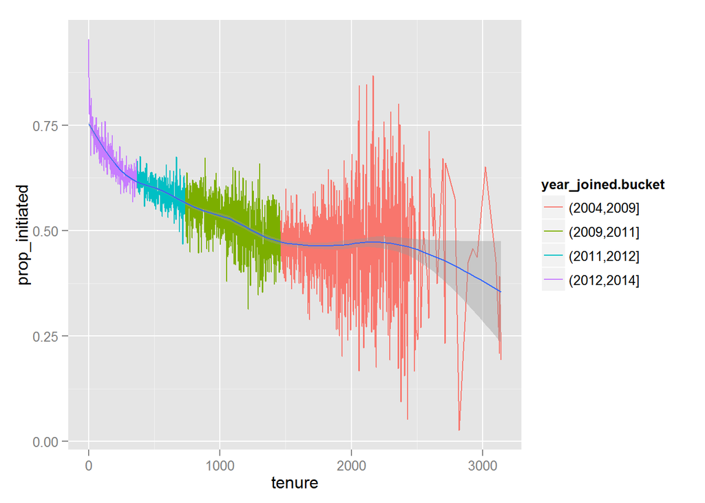

```r
# Smooth the last plot you created of
# of prop_initiated vs tenure colored by
# year_joined.bucket. You can bin together ranges
# of tenure or add a smoother to the plot.

# There won't be a solution image for this exercise.
# You will answer some questions about your plot in
# the next two exercises.

# This assignment is not graded and
# will be marked as correct when you submit.

# ENTER YOUR CODE BELOW THIS LINE
# ====================================================
ggplot(data=pf.subset, aes(x=tenure, y=prop_initiated)) +
  stat_summary(fun.y=mean, geom="line", aes(color=year_joined.bucket)) +
  geom_smooth()
```

## 8- Greatest prop_initiated Group

On overage, which group initiated the greatest proportion of its Facebook friendships? The plot with the smoother that you created in the last exercise can help you answer this question?

- People who joined prior to 2009
- People who joined 2009-2011
- People who joined 2011-2012
- **People who joined after 2012**

## 9- Largest Group Mean prop_initiated

**For the group with the largest proportion of friendships initiated, what is the group’s average (mean) proportion of friendships initiated?** 0.6653892

```r
library(dplyr)
pf.subset %>% group_by(year_joined.bucket) %>% summarize(mean_prop_initiated=mean(prop_initiated))
```

```
## Source: local data frame [5 x 2]
##
##   year_joined.bucket mean_prop_initiated
##               (fctr)               (dbl)
## 1        (2004,2009]           0.4668151
## 2        (2009,2011]           0.5301298
## 3        (2011,2012]           0.5984577
## 4        (2012,2014]           0.6653892
## 5                 NA           0.6168644
```

**Why do you think this group’s proportion of friendships initiated is higher than the others?** – They are often times “late joiners to the game” and have a bigger user base to choose from.

# Revisiting the Diamonds Dataset

## 10- Price/Carat Binned, Faceted, & Colored

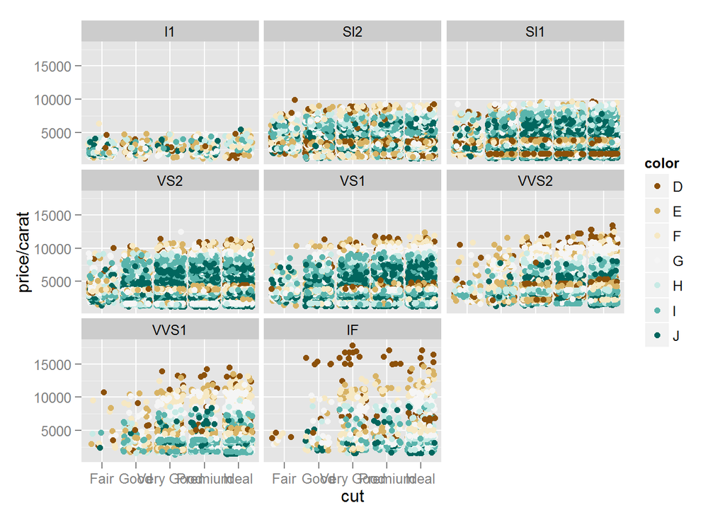

```r
# Create a scatter plot of the price/carat ratio
# of diamonds. The variable x should be
# assigned to cut. The points should be colored
# by diamond color, and the plot should be
# faceted by clarity.

# The plot should look something like this.
# http://i.imgur.com/YzbWkHT.jpg.

# Note: In the link, a color palette of type
# 'div' was used to color the histogram using
# scale_color_brewer(type = 'div')

# This assignment is not graded and
# will be marked as correct when you submit.

# ENTER YOUR CODE BELOW THIS LINE
# ===========================================
ggplot(data=diamonds, aes(x=cut, y=price/carat)) +
  geom_jitter(aes(color=color)) +
  scale_color_brewer(type = 'div') +
  facet_wrap(~clarity)
```

***

# Gapminder Dataset

## 11- Gapminder Multivariate Analysis

```r
# The Gapminder website contains over 500 data sets with information about
# the world's population. Your task is to continue the investigation you did at the
# end of Problem Set 4 or you can start fresh and choose a different
# data set from Gapminder.

# If you’re feeling adventurous or want to try some data munging see if you can
# find a data set or scrape one from the web.

# In your investigation, examine 3 or more variables and create 2-5 plots that make
# use of the techniques from Lesson 5.

# You can find a link to the Gapminder website in the Instructor Notes.

# Once you've completed your investigation, create a post in the discussions that includes:
#       1. the variable(s) you investigated, your observations, and any summary statistics
#       2. snippets of code that created the plots
#       3. links to the images of your plots

# Copy and paste all of the code that you used for
# your investigation, and submit it when you are ready.
# ============================================================================================
library(GGally)
read.gapminder.data <- function(filename, v) {
  filedata <- read.csv(filename, header=T, check.names=F)
  filedata <- filedata %>%
    tidyr::gather("Year", "Value", 2:length(filedata)) %>%
    dplyr::filter(!is.na(Value))
  filedata$Year <- as.numeric(levels(filedata$Year))[filedata$Year]
  colnames(filedata)[1] <- "Country"
  tidydata <- filedata %>%
    dplyr::group_by(Country) %>%
    dplyr::summarise(Year=max(Year)) %>%
    dplyr::left_join(filedata, c("Year" = "Year", "Country" = "Country"))
  colnames(tidydata)[2] <- paste(c("Year.", v), collapse="")
  colnames(tidydata)[3] <- v
  return(tidydata)
}

cc <- c("Country" = "Country")
gapminder.data <- suppressWarnings(
    read.gapminder.data("indicator gapminder gdp_per_capita_ppp.csv", "GDPPerCapita") %>%
    dplyr::left_join(read.gapminder.data("indicator gapminder under5mortality.csv", "Under5Mortality"), cc) %>%
    dplyr::left_join(read.gapminder.data("indicator_crude birth rate (births per 1000 population).csv", "BirthPer1000"), cc) %>%
    dplyr::left_join(read.gapminder.data("indicator_one-year-olds immunized with three doses of hepatitis b (hepb3) (%).csv", "VaccinatedP"), cc) %>%
    dplyr::left_join(read.gapminder.data("Years in school women 15 to 44.csv", "WomenAvgYearsInSchool"), cc) %>%
    dplyr::filter(!is.na(GDPPerCapita) & !is.na(Under5Mortality) & !is.na(BirthPer1000) & !is.na(VaccinatedP) & !is.na(WomenAvgYearsInSchool))
  )

# master plot to show corellation between any two variables
gapminder.data.subset <- gapminder.data[, c(3,5,7,9,11)]
names(gapminder.data.subset)
```

```
## [1] "GDPPerCapita"          "Under5Mortality"       "BirthPer1000"
## [4] "VaccinatedP"           "WomenAvgYearsInSchool"
```

```r
names(gapminder.data.subset)
```

```
## [1] "GDPPerCapita"          "Under5Mortality"       "BirthPer1000"
## [4] "VaccinatedP"           "WomenAvgYearsInSchool"
```

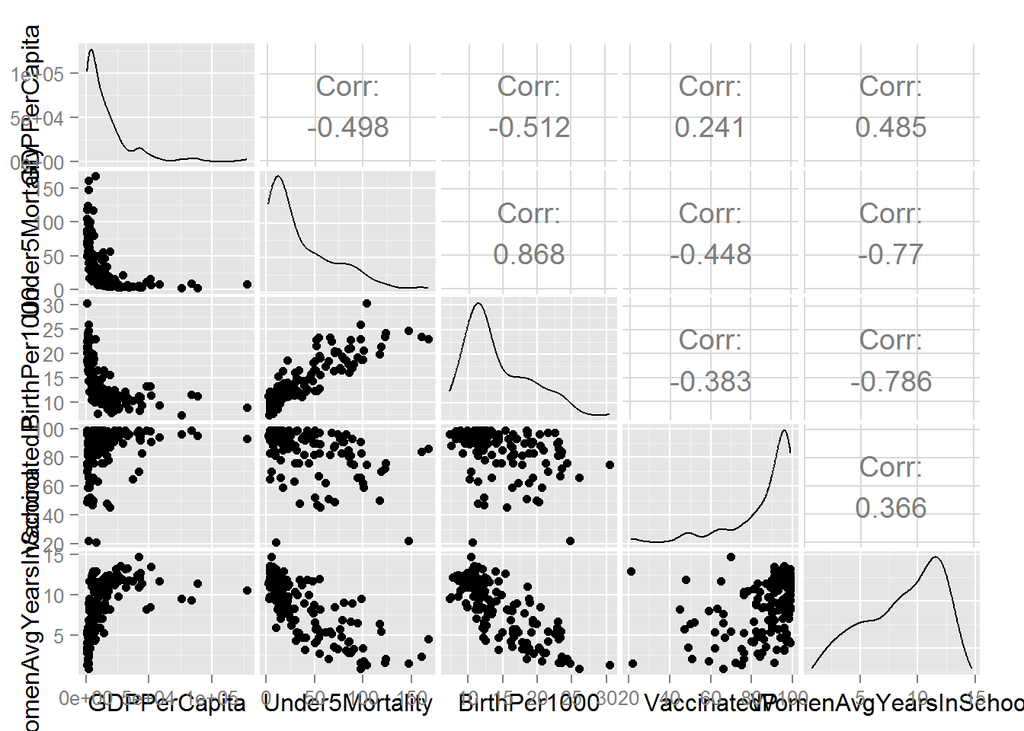

```r
ggpairs(gapminder.data.subset)
```

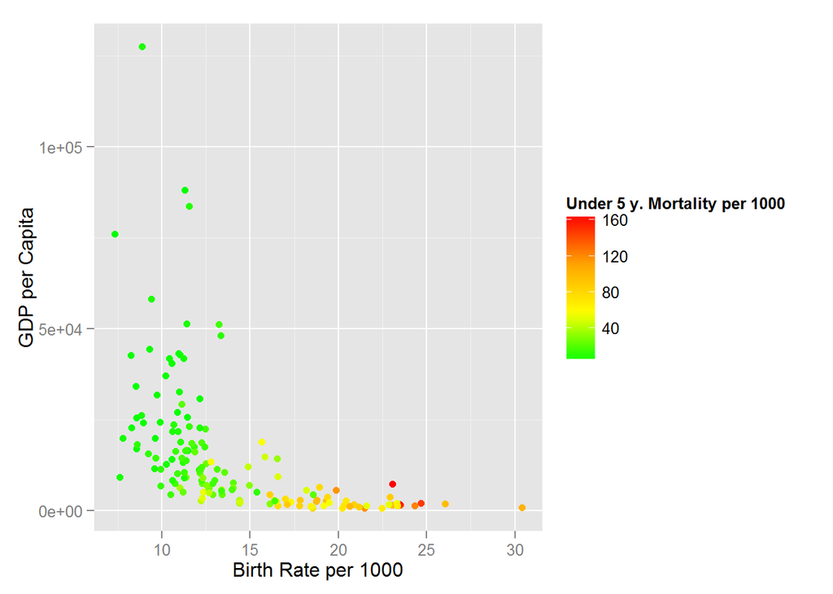

```r
color.spread = floor(max(gapminder.data.subset$Under5Mortality)-min(gapminder.data.subset$Under5Mortality))

# Under 5 y Mortality depending on Birth Rate & GDP per Capita
ggplot(data=gapminder.data.subset, aes(y = GDPPerCapita, x = BirthPer1000)) +
  geom_point(aes(color = Under5Mortality)) +
  scale_color_gradientn(colours=colorRampPalette(c("green", "yellow", "orange", "red"))(color.spread), name="Under 5 y. Mortality per 1000") +
  xlab("Birth Rate per 1000") +
  ylab("GDP per Capita")
```

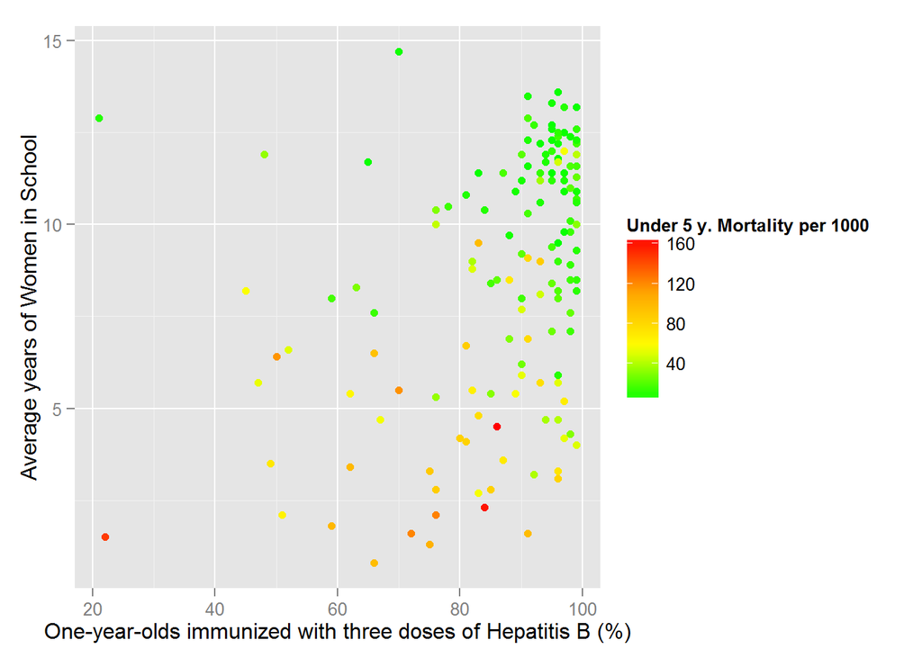

```r
# Under 5 y Mortality depending on Birth Rate & GDP per Capita
ggplot(data=gapminder.data.subset, aes(y = WomenAvgYearsInSchool, x = VaccinatedP)) +
  geom_point(aes(color = Under5Mortality)) +
  scale_color_gradientn(colours=colorRampPalette(c("green", "yellow", "orange", "red"))(color.spread), name="Under 5 y. Mortality per 1000") +
  xlab("One-year-olds immunized with three doses of Hepatitis B (%)") +
  ylab("Average years of Women in School")
```